# 3. Identifying DEGs comparing MUT vs WT cells of the same clonotype (MR4050)

Friederike Dündar

July 2021; updated 2022-02-08

```r
library(data.table)
library(magrittr)
library(SingleCellExperiment)
library(ggplot2); theme_set(theme_bw(base_size = 16) )
library(ggrepel)
library(patchwork)
##library(KlebanoffMR4050)
devtools::load_all("/Users/frd2007/Documents/Projects/2018-10_Smita/chris-klebanoff/KlebanoffMR4050")
```

```r
## based on what we saw in `IdentifyingReactiveClonotype.Rmd`
winner <- "TRB:CASSADSSNTGELFF;TRA:CAVRDPLSNFGNEKLTF"
winner_TRB <- "TRB:CASSADSSNTGELFF"
non_winner <- "TRB:CAWSWGYNTIYF;TRA:CAVGTGANNLFF" # clonotype with negative delta IFNg
#rare_ct <- "TRA:CVVNFRNSGNTPLVF;TRB:CSARLNIQYF"
```

```r
cdrsMR4050 <- list(winner, winner_TRB, non_winner)#, rare_ct)
usethis::use_data(cdrsMR4050)
```

# Identifying genes that are DE in MUT vs. WT cells of the same clonotype

The main goal of the bioinformatic analyses is to identify TCR clonotypes that show a selective response against the antigen presented by the APCs. These should include T cells that show high values for acute T cell activation, but the same clonotypes should *not* show significant activation when exposed to the irrelevant antigen. This is how we determined the “winning” clonotype: by simply assessing the difference of IFNG levels.

In principle, we’re expecting three groups of T cells:

- **specific responders**: higher activation in the presence of the tumor compared to the irrelevant antigen
- **unspecific responders**: similarly high activation markers in both antigen conditions;
- **non-responders**: no expression of activation markers.

```r
## Load the SCE with the shared clonotypes
#sce.shared <- readRDS(file = "~/Documents/Projects/2018-10_Smita/data/sce_sharedClonotypes_Mar2020.RDS")
sce.shared <- load_MR4050shared()
```

```
#> Cached data here: ~/Library/Caches/BiocFileCache/395e85e6940_bhxr35emjmrh9038m0i2l04ltmb4sb7m.rds
#> Cached data here: ~/Library/Caches/BiocFileCache/395e6e4fed0a_6avefij9qpzne2sodv3a90kn19crdmfm.rds
#> Cached data here: ~/Library/Caches/BiocFileCache/395e4153641a_s5ornq6t0iiini2n3bxim7wobpe15jr1.rds
#> Cached data here: ~/Library/Caches/BiocFileCache/395e49d10877_zi1o023ywlyzck7z1jb3y51y71f6taa2.rds
#> Cached data here: ~/Library/Caches/BiocFileCache/395e3a82e27d_wfqb7okunh75pc921p498r8o2j7owl8b.rds
```

```r
ifng.dt <- scABC2::make_long_dt(sce.shared,
  exprs_values = "logcounts", features = "IFNG",
  include_metaData=c("Sample", "id"))
setnames(ifng.dt, "feature_name","gene_name")
```

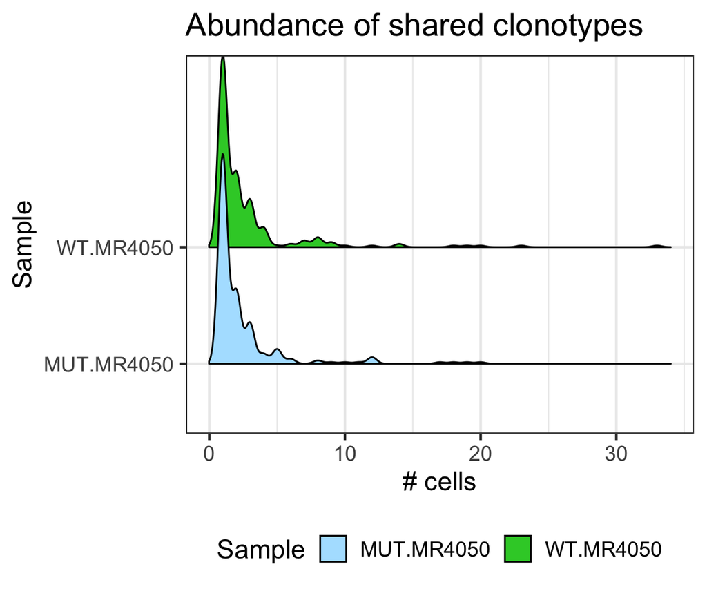

```r
ifng.dt[, .N, c("Sample","id")] %>%
 ggplot(., aes(x = N, y = Sample, fill = Sample)) +
  ggridges::geom_density_ridges2() +
  ggtitle("Abundance of shared clonotypes") +
  xlab("# cells") +
  theme(legend.position = "bottom") +
  scale_fill_manual(values = c("lightskyblue1","limegreen"))
```

The shared clonotypes represent the full spectrum of clonotype frequencies, i.e. the majority is present less than 10 times. As we saw in the first vignette, the most abundant clonotypes are not necessarily the most reactive ones in terms of IFNG expression.

## Differentially expressed genes: MUT vs. WT

We’re going to **run DE for every clonotype**, comparing MUT vs. WT. `run_DE` is a wrapper function around `scran::findMarkers()`.

```r
sce.shared$antigen <-  factor(gsub("\\..*","",sce.shared$Sample), levels = c("WT", "MUT"), ordered = TRUE)

delist.both <- lapply( unique(sce.shared$id), function(x){
    print(x)
  run_DE(
    sce.shared[, sce.shared$id == x],
    group_identifier = "antigen",
    direction = "any",
    FDR = 0.05, rank = Inf,
    comp_name = paste0(x, "_"))
})
names(delist.both) <- unique(sce.shared$id)

## determine those clonotypes for which the DE returned something
#with_deg <- lapply(delist.both, function(x) !is.null(x[[2]])) %>% unlist
#delist.both <- delist.both[with_deg]

## only keep those for which scater::findMarkers was able to run (i.e.,
## there were at least 2 samples per condition
no_NA <- sce.shared[, sce.shared$fit_for_test]$id %>% unique
delist.both <- delist.both[no_NA]
#usethis::use_data(delist.both[no_NA], overwrite = TRUE) ## moved to Box
## upload the following file to Box --> KlebanoffLab_singleCellData/
##!save(delist.both, file = "/Users/frd2007/Documents/Projects/2018-10_Smita/2021-07_ProcessingMR4050/delist.both_MR4050.rda")
```

```
#> Cached data here: ~/Library/Caches/BiocFileCache/17d7a1a4812ff_1xgjtul76efnnhqu78goa8lsmeuydlq4.rda
```

The only clonotypes for which DEG were detected are: C19, C160, C24.

This corresponds to the following clonotypes:

```r
sce.shared[, sce.shared$id %in% names(delist.both[with_deg])] %>%
  colData %>% .[, c("cdr3s_aa", "id")] %>% unique %>%
  as.data.frame %>% my_table
```

| cdr3s_aa | id |
| --- | --- |
| TRB:CASSADSSNTGELFF;TRA:CAVRDPLSNFGNEKLTF | C19 |
| TRB:CASSYSGGGLYEQYF;TRA:CAAHNDYKLSF | C160 |
| TRB:CASSALYPPLGYNEQFF;TRA:CAGLFMNYGGATNKLIF | C24 |

## Results

```r
delist.both[["C24"]]
```

```
#> $findMarkers_results
#> List of length 1
#> names(1): MUT
#>
#> $marker_IDs
#>     gene_symbol   up_in classify
#>  1:       PSMA6  C24_WT   unique
#>  2:      NAP1L1  C24_WT   unique
#>  3:       EIF3H  C24_WT   unique
#>  4:        PIGT C24_MUT   unique
#>  5:        ECI2 C24_MUT   unique
#>  6:      ZNF808 C24_MUT   unique
#>  7:       JOSD1 C24_MUT   unique
#>  8:      GOLGB1 C24_MUT   unique
#>  9:       RPS17 C24_MUT   unique
#> 10:      ZNF644 C24_MUT   unique
#> 11:    ARHGAP25 C24_MUT   unique
#> 12:      BTN3A2 C24_MUT   unique
```

| Symbol | Name | Comment |
| --- | --- | --- |
| PSMA6 |  |  |
| NAP1L1 |  |  |
| EIF3H |  |  |
| PIGT |  |  |
| ECI2 |  |  |
| JOSD1 |  |  |
| GOLGB1 |  |  |
| ARHGAP25 |  |  |
| BTN3A2 |  |  |

```r
delist.both[["C160"]]
```

```
#> $findMarkers_results
#> List of length 1
#> names(1): MUT
#>
#> $marker_IDs
#>    gene_symbol    up_in classify
#> 1:      MAGED2 C160_MUT   unique
#> 2:      LSM14B C160_MUT   unique
#> 3:     BCL2L12 C160_MUT   unique
#> 4:       YIPF2 C160_MUT   unique
#> 5:       RNF25 C160_MUT   unique
#> 6:       YPEL3 C160_MUT   unique
#> 7:       SATB1 C160_MUT   unique
```

| Symbol | Name | Comment |
| --- | --- | --- |
| MAGED2 |  |  |
| LSM14B |  |  |
| BCL2L12 |  |  |
| YIPF2 |  |  |
| RNF25 |  |  |
| YPEL3 |  |  |
| SATB1 |  |  |

# Saving tables for Chris

```r
## saving logFC values for most frequent clonotypes
freq_clones <- sce.shared[, sce.shared$freq_across_all > 20]$id %>% unique
## ...and those for which we've found DE genes
de_clones <- names(delist.both[with_deg])

## will save them all in one xlsx collection of spreadsheets
outl <- lapply(unique(c(freq_clones, de_clones)), function(x){
  degns <- delist.both[[x]]$findMarkers_results$MUT %>% as.data.frame %>%
    as.data.table(., keep.rownames="gene_symbol")
  degns[, neglog10.pVal := -1*log10(p.value)]
  degns[, neglog10.FDR := -1*log10(FDR)]
  return(data.frame(degns))
})
names(outl) <- paste(unique(c(freq_clones, de_clones), "DEG_Mut-vs-Wt", sep = "_"))

## add basic information about the clonotypes
cinfo <-  clonotype_ids[id %in% unique(c(freq_clones, de_clones))]
setnames(cinfo, c("MUT.MR4050", "WT.MR4050"), c("n_cells_in_MUT", "n_cells_in_WT"))
setorder(cinfo, id)
outl$clonotype_info <- data.frame(cinfo)

openxlsx::write.xlsx(outl,
  file = "/Users/frd2007/Documents/Projects/2018-10_Smita/2021-07_ProcessingMR4050/DEgenes_MR4050.xlsx")
```

```r
data("clonotype_ids", package = "KlebanoffMR4050")
as.data.frame(clonotype_ids) %>% write.table(., quote = F, sep ="\t", row.names =F,
  file = "/Users/frd2007/Documents/Projects/2018-10_Smita/2021-07_ProcessingMR4050/MR4050_clonotypeIDs.txt")
```

“For MR4050, can we please get the RNA-seq reads for the lineage markers (CD3, CD4 and CD8) of the winning clonotype, C19.”

```r
gns <- c("CD3E", "CD4","CD8A")
## iwnner == C19
sce.shared[gns, sce.shared$cdr3s_aa == winner] %>% logcounts %>% t %>% as.matrix %>% as.data.frame %>%
  write.table(.,"/Users/frd2007/Documents/Projects/2018-10_Smita/2021-07_ProcessingMR4050/MR4050_C19_Winner_logcounts_CD3-4-8.txt", sep = "\t", quote=FALSE, row.names = TRUE, col.names = TRUE)
```